# Database Project Part 2: Ziliotto

### Connect database:

```python
import pandas as pd # general convention is to use pd to represent pandas
import numpy as np
import matplotlib.pyplot as plt
import sqlalchemy
from sqlalchemy.engine import URL
import StatTests
#pyodbc stuff for MS SQL Server
driver='{SQL Server}'
server='DESKTOP-640NG9G\MSSQLSERVR'
database='CieloVolo'
trusted_connection='yes'

#pyodbc connection string
connection_string = f'DRIVER={driver};SERVER={server};'
connection_string += f'DATABASE={database};'
connection_string += f'TRUSTED_CONNECTION={trusted_connection}'

#create sqlalchemy engine connection URL string
connection_url = URL.create(
    "mssql+pyodbc", query={"odbc_connect": connection_string})
connection = sqlalchemy.create_engine(connection_url)
```

## Business Graphing Q1:

### How do the revenues generated by AirportDestination differ? Secondly, how do revenues by AirportOrigin differ?

```python
q_airport = '''SELECT
SUM(t.TicketPrice) AS TotalTicketRevenue,
fd.AirportID AS 'AirportDestination'
FROM
Ticket t
INNER JOIN Flight f ON t.FlightID = f.FlightID
INNER JOIN FlightOrigin fo ON f.FlightID = fo.FlightID
INNER JOIN FlightDestination fd ON f.FlightID = fd.FlightID
INNER JOIN EmployeeSchedule es ON f.FlightID = es.FlightID
GROUP BY
fd.AirportID
;'''
df_airport = pd.read_sql(q_airport,connection)
df_airport.head()
```

|  | TotalTicketRevenue | AirportDestination |
| --- | --- | --- |
| 0 | 209879.11 | MSY |
| 1 | 206979.57 | BOS |
| 2 | 206389.84 | DTW |
| 3 | 204231.42 | MSP |
| 4 | 196922.01 | SFO |

```python
q_airport2 = '''SELECT
t.FlightID,
SUM(t.TicketPrice) AS TotalTicketRevenue,
fo.AirportID AS 'AirportOrigin'
FROM
Ticket t
INNER JOIN Flight f ON t.FlightID = f.FlightID
INNER JOIN FlightOrigin fo ON f.FlightID = fo.FlightID
INNER JOIN FlightDestination fd ON f.FlightID = fd.FlightID
INNER JOIN EmployeeSchedule es ON f.FlightID = es.FlightID
GROUP BY
t.FlightID,
fo.AirportID
;'''
df_airport2 = pd.read_sql(q_airport2,connection)
df_airport2.head()
```

|  | FlightID | TotalTicketRevenue | AirportOrigin |
| --- | --- | --- | --- |
| 0 | 102 | 3749.811 | LAX |
| 1 | 309 | 4265.610 | PDX |
| 2 | 887 | 2950.310 | ORD |
| 3 | 961 | 2372.490 | DTW |
| 4 | 716 | 6362.960 | JFK |

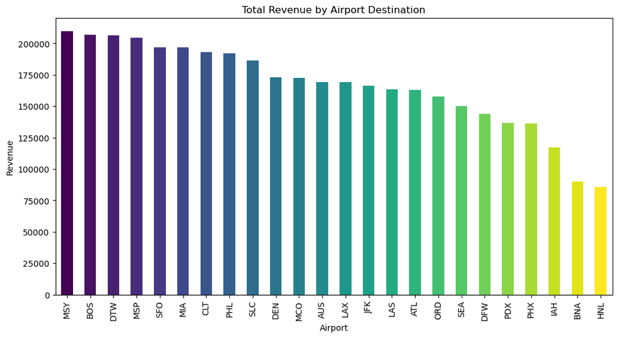

```python
df_sorted = df_airport.groupby('AirportDestination')['TotalTicketRevenue'].sum().sort_values(ascending=False)
plt.figure(figsize=(12, 6))
colors = plt.cm.viridis(np.linspace(0, 1, len(df_sorted)))
df_sorted.plot(kind='bar', color=colors)
plt.title(f"Total Revenue by Airport Destination")
plt.xlabel('Airport')
plt.ylabel('Revenue')
plt.show()
```

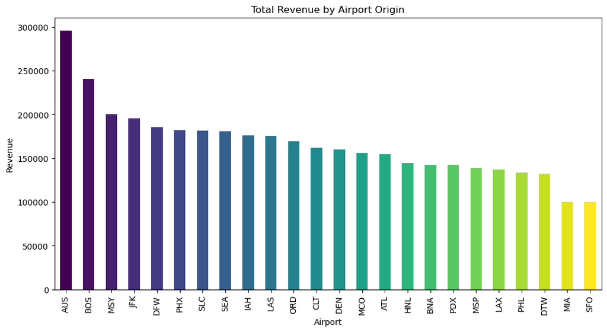

```python
df_sorted2 = df_airport2.groupby('AirportOrigin')['TotalTicketRevenue'].sum().sort_values(ascending=False)
plt.figure(figsize=(12, 6))
colors = plt.cm.viridis(np.linspace(0, 1, len(df_sorted2)))
df_sorted2.plot(kind='bar', color=colors)
plt.title(f"Total Revenue by Airport Origin")
plt.xlabel('Airport')
plt.ylabel('Revenue')
plt.show()
```

##### Provide your conclusions that includes the interpretation of the results and the “so what?”

As we can see, the top revenues by airport origin and destination differ quite a bit. This gives CieloVolo a good understanding of which origin airports are either most flown out of or simply most revenue driving. Similarly, Cielovolo can see which flight airport destinations generates the greatest revenues. This is important to consider when expanding operations or altering ticket prices.

## Business Graphing Q2:

### How does the flight duration in minutes relate to the number of employees scheduled on a flight?

```python
q_sch = '''SELECT
COUNT(es.EmployeeID) AS EmployeesScheduled,
CASE
WHEN f.FlightArrival >= f.FlightDeparture THEN
DATEDIFF(MINUTE, CAST('1900-01-01' AS datetime) + CAST(f.FlightDeparture AS datetime), CAST('1900-01-01' AS datetime) + CAST(f.FlightArrival AS datetime))
ELSE
DATEDIFF(MINUTE, CAST('1900-01-01' AS datetime) + CAST(f.FlightDeparture AS datetime), DATEADD(DAY, 1, CAST('1900-01-01' AS datetime) + CAST(f.FlightArrival AS datetime)))
END AS FlightDurationMins
FROM
Flight f
INNER JOIN FlightOrigin fo ON f.FlightID = fo.FlightID
INNER JOIN FlightDestination fd ON f.FlightID = fd.FlightID
INNER JOIN EmployeeSchedule es ON f.FlightID = es.FlightID
GROUP BY f.FlightArrival,
f.FlightDeparture
;'''
df_sch = pd.read_sql(q_sch,connection)
df_sch.head()
```

|  | EmployeesScheduled | FlightDurationMins |
| --- | --- | --- |
| 0 | 3 | 706 |
| 1 | 1 | 154 |
| 2 | 2 | 135 |
| 3 | 1 | 773 |
| 4 | 1 | 973 |

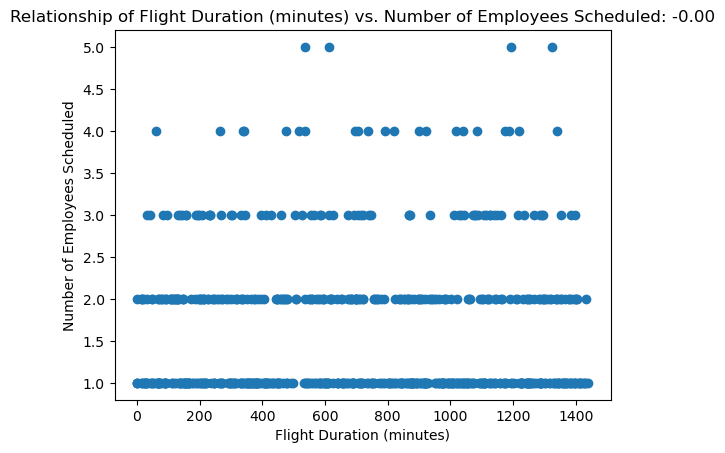

```python
dur_sch=np.corrcoef(df_sch['FlightDurationMins'],df_sch['EmployeesScheduled'])[0][1]

plt.scatter(df_sch['FlightDurationMins'],df_sch['EmployeesScheduled'])
plt.title(f"Relationship of Flight Duration (minutes) vs. Number of Employees Scheduled: {dur_sch:.2f}")
plt.xlabel('Flight Duration (minutes)')
plt.ylabel('Number of Employees Scheduled')
plt.show()
```

##### Provide your conclusions that includes the interpretation of the results and the “so what?”

The comparison between flight duration and employees scheduled shows a lack of linear correlation with a value of -0.0. This means that employees aren't being scheduled with flight duration in mind, which could become a labor rights issue and result in negative consumer experience.

## Business Statistical Analysis Q1:

### Is there a significant difference in the revenue generated from ticket prices based on the aircraft type?

```python
q_aircraft = '''SELECT FlightAircraft
, TicketPrice
FROM Ticket t
INNER JOIN Flight f
ON t.FlightID = f.FlightID
GROUP BY FlightAircraft, TicketPrice
ORDER BY FlightAircraft ASC, TicketPrice DESC
;'''
df_aircraft = pd.read_sql(q_aircraft,connection)
df_aircraft.head()
```

|  | FlightAircraft | TicketPrice |
| --- | --- | --- |
| 0 | Airbus | 3182.57 |
| 1 | Airbus | 3081.47 |
| 2 | Airbus | 3030.92 |
| 3 | Airbus | 2828.72 |
| 4 | Airbus | 2727.62 |

### ANOVA test:

```
The groups are Airbus and Boeing 777 and Boeing 787 and Embraer E-170 and Embraer E-175
This is a test of equal means with Ho: The means of all groups are equal/Ha: At least one group mean is different
The F test statistic is 1.514 and the p-value is 0.1952
Conclusion: Fail to Reject Ho: We can't reject that the means are the same
```

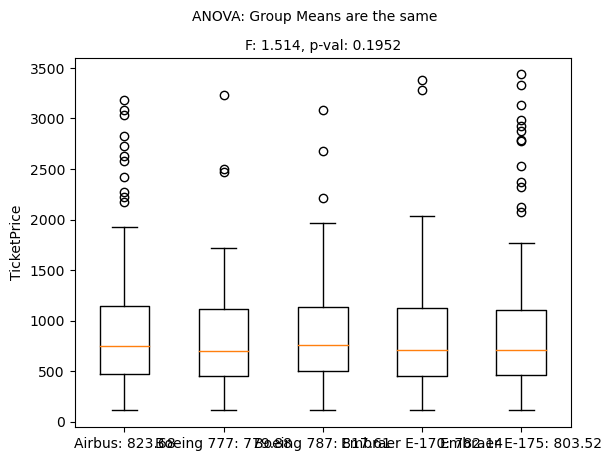

```
Ho: The group means are equal
        Multiple Comparison of Means - Tukey HSD, FWER=0.05
====================================================================
    group1        group2    meandiff p-adj    lower    upper  reject
--------------------------------------------------------------------
       Airbus    Boeing 777 -43.7961 0.3434 -108.3051 20.7129  False
       Airbus    Boeing 787  -6.0637 0.9992   -72.478 60.3506  False
       Airbus Embraer E-170 -41.5421 0.3159 -101.1229 18.0387  False
       Airbus Embraer E-175 -20.1572 0.9143  -84.7628 44.4484  False
   Boeing 777    Boeing 787  37.7324 0.5393  -29.3282 104.793  False
   Boeing 777 Embraer E-170    2.254    1.0  -58.0463 62.5543  False
   Boeing 777 Embraer E-175  23.6389 0.8607  -41.6309 88.9087  False
   Boeing 787 Embraer E-170 -35.4784 0.5277  -97.8129 26.8561  False
   Boeing 787 Embraer E-175 -14.0934  0.979   -81.247 53.0601  False
Embraer E-170 Embraer E-175  21.3849 0.8703  -39.0187 81.7886  False
--------------------------------------------------------------------
```

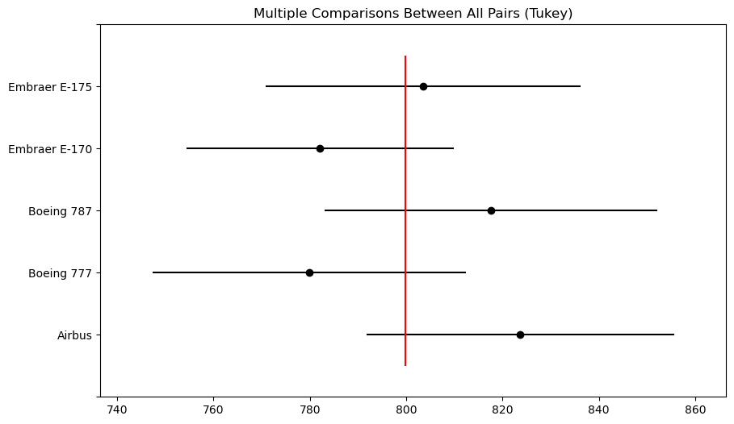

```python
StatTests.MeansTest(df_aircraft,'FlightAircraft', 'TicketPrice')
```

##### Provide your conclusions that includes the interpretation of the results and the “so what?”

When comparing the ticket prices of each aircraft type, the means show no signficant difference (all means > p-val, meaning no signicant difference in means & an acceptance of the hypothesis), suggesting at there is not a large difference in ticket prices between each aircraft type. This is strange, as different sized aircrafts require different amounts of fuel. This exposes a possible issue in appropriate pricing to cover the costs of each flight.

## Business Statistical Analysis Q2:

### How do the number of tickets sold, employee scheduled, and flight duration affect the total revenue for each flight?

```python
q_ticket = '''SELECT
t.FlightID,
COUNT(t.FlightID) AS TotalTicketQty,
COUNT(es.EmployeeID) AS EmployeesScheduled,
SUM(t.TicketPrice) AS TotalTicketRevenue,
f.FlightAircraft,
CASE
WHEN f.FlightArrival >= f.FlightDeparture THEN
DATEDIFF(MINUTE, CAST('1900-01-01' AS datetime) + CAST(f.FlightDeparture AS datetime), CAST('1900-01-01' AS datetime) + CAST(f.FlightArrival AS datetime))
ELSE
DATEDIFF(MINUTE, CAST('1900-01-01' AS datetime) + CAST(f.FlightDeparture AS datetime), DATEADD(DAY, 1, CAST('1900-01-01' AS datetime) + CAST(f.FlightArrival AS datetime)))
END AS FlightDurationMins,
t.TicketDate,
fo.AirportID AS 'AirportOrigin',
fd.AirportID AS 'AirportDestination'
FROM
Ticket t
INNER JOIN Flight f ON t.FlightID = f.FlightID
INNER JOIN FlightOrigin fo ON f.FlightID = fo.FlightID
INNER JOIN FlightDestination fd ON f.FlightID = fd.FlightID
INNER JOIN EmployeeSchedule es ON f.FlightID = es.FlightID
GROUP BY
t.FlightID,
f.FlightAircraft,
t.TicketDate,
fo.AirportID,
fd.AirportID,
f.FlightDeparture,
f.FlightArrival
ORDER BY
t.FlightID ASC
;'''
df_ticket = pd.read_sql(q_ticket,connection)
df_ticket.head()
```

|  | FlightID | TotalTicketQty | EmployeesScheduled | TotalTicketRevenue | FlightAircraft | FlightDurationMins | TicketDate | AirportOrigin | AirportDestination |
| --- | --- | --- | --- | --- | --- | --- | --- | --- | --- |
| 0 | 2 | 15 | 15 | 10133.97 | Embraer E-170 | 235 | 2024-02-02 | PDX | MSP |
| 1 | 3 | 5 | 5 | 3554.14 | Airbus | 67 | 2024-02-05 | BNA | CLT |
| 2 | 4 | 5 | 5 | 3480.47 | Embraer E-170 | 315 | 2023-09-22 | SEA | AUS |
| 3 | 5 | 5 | 5 | 4598.06 | Boeing 787 | 584 | 2023-10-20 | JFK | PHL |
| 4 | 6 | 10 | 10 | 7692.70 | Airbus | 509 | 2023-06-01 | ORD | MIA |

### Regression (multiple):

```python
from statsmodels.formula.api import ols
# Define output variable (y): AskingPrice
# and input variables (x): LotSize
ticketmodel = ols("TotalTicketRevenue ~ TotalTicketQty + FlightDurationMins + EmployeesScheduled",data=df_ticket).fit()
print(ticketmodel.summary()) # Print the results
```

```
                            OLS Regression Results
==============================================================================
Dep. Variable:     TotalTicketRevenue   R-squared:                       0.858
Model:                            OLS   Adj. R-squared:                  0.858
Method:                 Least Squares   F-statistic:                     2039.
Date:                Tue, 28 May 2024   Prob (F-statistic):          8.77e-287
Time:                        21:52:28   Log-Likelihood:                -5805.5
No. Observations:                 678   AIC:                         1.162e+04
Df Residuals:                     675   BIC:                         1.163e+04
Df Model:                           2
Covariance Type:            nonrobust
======================================================================================
                         coef    std err          t      P>|t|      [0.025      0.975]
--------------------------------------------------------------------------------------
Intercept            168.8263    129.253      1.306      0.192     -84.960     422.613
TotalTicketQty       393.5263      6.163     63.849      0.000     381.425     405.628
FlightDurationMins     0.0554      0.115      0.481      0.631      -0.171       0.282
EmployeesScheduled   393.5263      6.163     63.849      0.000     381.425     405.628
==============================================================================
Omnibus:                       72.597   Durbin-Watson:                   1.764
Prob(Omnibus):                  0.000   Jarque-Bera (JB):              482.609
Skew:                           0.139   Prob(JB):                    1.60e-105
Kurtosis:                       7.124   Cond. No.                     2.74e+18
==============================================================================

Notes:
[1] Standard Errors assume that the covariance matrix of the errors is correctly specified.
[2] The smallest eigenvalue is 6.02e-29. This might indicate that there are
strong multicollinearity problems or that the design matrix is singular.
```